# GR5058 Data Mining Final Project

## Prediciting with Lagged GDP, ForEx, and Adj. Close Prices

Here we re-include time, using the original data frame called `data`, and we lag some of the variables we think may be of interest: `gdp`, `us_uk`, `us_mxp`, `us_bzr`, `dgx_adj_close`, and `lh_adj_close`. It may be that the current price at time t is also dependent on price or gdp or other variable at time t-1, so we’ll try lagged data. We’ll go from 1 to 2 lags indicating 1 week and 2 weeks prior.

```r
data$gdp_tminus1 <- lag(data$gdp, 1)
data$gdp_tminus2 <- lag(data$gdp, 2)

data$us_uk_tminus1 <- lag(data$us_uk, 1)
data$us_uk_tminus2<- lag(data$us_uk, 2)

data$us_mxp_tminus1 <- lag(data$us_mxp, 1)
data$us_mxp_tminus2 <- lag(data$us_mxp, 2)

data$us_bzr_tminus1 <- lag(data$us_bzr, 1)
data$us_bzr_tminus2 <- lag(data$us_bzr, 2)

data$dgx_adj_close_tminus1 <- lag(data$dgx_adj_close, 1)
data$dgx_adj_close_tminus2 <- lag(data$dgx_adj_close, 2)

data$lh_adj_close_tminus1 <- lag(data$lh_adj_close, 1)
data$lh_adj_close_tminus2 <- lag(data$lh_adj_close, 2)

data$quarter <- NULL

data <- data %>% drop_na() # we lose a few obs due to lagged data
```

#### Model 5 - Linear Regression

```r
# train test split
set.seed(12202019)
in_train <- createDataPartition(y = data$dgx_adj_close, p = .65, list = FALSE)
training <- data[ in_train, ]
testing  <- data[-in_train, ]

set.seed(12202019)
ctrl <- trainControl(method = "cv", number = 15)
lmt1  <- train(dgx_adj_close ~ ., data = training, method = 'lm',
               trControl = ctrl, preProcess = c("center", "scale"), na.action = na.omit)
lmt1_y_hat <- predict(lmt1, newdata = testing, na.action = na.pass)

lmt1_rmse <- defaultSummary(data.frame(obs = testing$dgx_adj_close, pred = lmt1_y_hat)); lmt1_rmse
```

```
##      RMSE  Rsquared       MAE
## 1.7336502 0.9452915 1.3357985
```

#### Model 6 - Decision Tree

```r
set.seed(12202019)
ctrl <- trainControl(method = "cv", number = 15)
dt1 <- train(dgx_adj_close ~ ., data = training, method = "rpart2",
              preProcess = c("center", "scale"), tuneLength = 10, trControl = ctrl, na.action = na.omit)
```

```
## note: only 4 possible values of the max tree depth from the initial fit.
##  Truncating the grid to 4 .
```

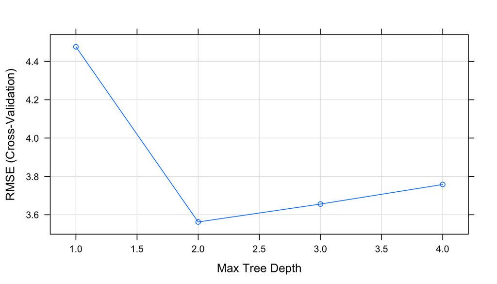

```r
plot(dt1)
```

```r
dt1_y_hat <- predict(dt1, newdata = testing, na.action = na.pass)

dt1_rmse <- defaultSummary(data.frame(obs = testing$dgx_adj_close, pred = dt1_y_hat)); dt1_rmse
```

```
##      RMSE  Rsquared       MAE
## 3.5651406 0.7452615 2.7802872
```

#### Model 7 - Random Forests

```r
set.seed(12202019)
ctrl <- trainControl(method = "cv", number = 15)
rf1_grid <- data.frame(.mtry = 2:(ncol(training) - 1L))

rf1 <- train(dgx_adj_close ~ ., data = training, method = "rf",
              preProcess = c("center", "scale"), trControl = ctrl, tuneGrid = rf_grid,
             ntrees = 1000, importance = T, na.action = na.omit)

#varImp(rf1)

rf1_y_hat <- predict(rf1, newdata = testing, na.action = na.pass)

rf1_rmse <- defaultSummary(data.frame(obs = testing$dgx_adj_close, pred = rf1_y_hat)); rf1_rmse
```

```
##      RMSE  Rsquared       MAE
## 2.6867381 0.8572364 1.9803317
```

#### Model 8 - Boosting

```r
set.seed(12202019)
ctrl <- trainControl(method = "cv", number = 20)
gbm_grid <- expand.grid(.interaction.depth = seq(1, 6, by = 1),
                        .n.trees = seq(100, 1000, by = 50),
                        .shrinkage = c(0.01, 0.1),
                        .n.minobsinnode = 1:5)

gbm1 <- train(dgx_adj_close ~ ., data = training, method = "gbm",
              preProcess = c("center", "scale"), trControl = ctrl, tuneGrid = gbm_grid, verbose = F, na.action = na.omit)
gbm1_y_hat <- predict(gbm1, newdata = testing, na.action = na.pass)

gbm1_rmse <- defaultSummary(data.frame(obs = testing$dgx_adj_close, pred = gbm1_y_hat)); gbm1_rmse
```

```
##      RMSE  Rsquared       MAE
## 2.4880101 0.8752176 1.7653643
```

#### Model 9 - BART

```r
set.seed(12202019)

n.trees_seq <- seq(from = 50, to = 100, by = 10)
power_seq <- seq(from = 1, to = 3, by = .5)
base_seq <- seq(from = .Machine$double.eps,
                to = 1 - .Machine$double.eps, by = .2)

bart1 <- xbart(dgx_adj_close ~ ., data = training,
               drop = F, verbose = F, n.reps = 10,
               n.threads = parallel::detectCores(),
               n.trees = n.trees_seq, power = power_seq, base = base_seq)

best <- as.data.frame(which(bart1 == min(bart1), arr.ind = T))

bart1_out <- bart2(dgx_adj_close ~ ., data = training, test = testing,
                     n.trees = n.trees_seq[best$n.trees],
                     base = base_seq[best$base],
                     power = power_seq[best$power])
```

[output not shown]

[output cut: 28 more lines]

[output not shown]

```r
bart1_rmse <- defaultSummary(data.frame(obs = testing$dgx_adj_close, pred = rowMeans(bart1_out$yhat.test))); bart1_rmse
```

```
##       RMSE   Rsquared        MAE
## 7.03893983 0.00130303 5.80869492
```

#### Model 10 - Neural Nets

```r
set.seed(12202019)
nnetGrid <- expand.grid(.decay = c(0, 0.001, 0.01, .1), .size = c(1:20))
ctrl <- trainControl(method = "cv", number = 20)

nn <- train(dgx_adj_close ~ ., data = training, method = "nnet",
            trControl = ctrl, tuneGrid = nnetGrid,
            preProcess = c("center", "scale"), trace = FALSE, na.action = na.omit)
nn_out <- predict(nn, newdata = testing, na.action = na.pass)

nn_rmse <- defaultSummary(data.frame(obs = testing$dgx_adj_close, pred = nn_out)); nn_rmse
```

```
##     RMSE Rsquared      MAE
## 96.93032       NA 96.67490
```

#### Model 11 - MARS

```r
set.seed(12202019)
ctrl <- trainControl("cv", number = 15)
marsGrid <- expand.grid(.degree = 1:3, .nprune = 1:10)

mars <- train(dgx_adj_close ~ ., data = testing, method = "earth",
              preProcess = c("center", "scale"), trControl = ctrl, tuneGrid = marsGrid)
mars_out <- predict(mars, newdata = testing)

mars_rmse <- defaultSummary(data.frame(obs = testing$dgx_adj_close, pred = mars_out[ , 1])); mars_rmse
```

```
##      RMSE  Rsquared       MAE
## 0.9947696 0.9799887 0.7487235
```

#### Model 12 - Logistic Regression

```r
set.seed(12202019)
ctrl <- trainControl("cv", number = 15)
tune_grid <- expand.grid(.alpha = seq(0, 1, length.out = 10),
                         .lambda = seq(0, 1, length.out = 10))

enet <- train(dgx_adj_close ~ ., data = training, method = "glmnet",
              preProcess = c("center", "scale"), trControl = ctrl, tuneGrid = tune_grid)
enet_out <- predict(enet, newdata = testing)

enet_rmse <- defaultSummary(data.frame(obs = testing$dgx_adj_close, pred = enet_out)); enet_rmse
```

```
##      RMSE  Rsquared       MAE
## 1.9085088 0.9330574 1.4517857
```

## Observations and Discussion

```r
model_t <- c('linear regression', 'decision tree', 'random forest', 'boosting' , 'BART', 'NN', 'MARS', 'penalized logit')
rmse_t <- c(lmt1_rmse[1], dt1_rmse[1], rf1_rmse[1], gbm1_rmse[1], bart1_rmse[1], nn_rmse[1], mars_rmse[1], enet_rmse[1])

performance2 <- as_tibble(cbind(model_t, rmse_t))

performance2$rmse_t <- as.numeric(performance2$rmse_t)

performance2 %>% arrange(rmse_t)
```

```
## # A tibble: 8 x 2
##   model_t           rmse_t
##   <chr>              <dbl>
## 1 MARS               0.995
## 2 linear regression  1.73
## 3 penalized logit    1.91
## 4 boosting           2.49
## 5 random forest      2.69
## 6 decision tree      3.57
## 7 BART               7.04
## 8 NN                96.9
```